# Auton et al. (2015) 1000 Genomes Phase 3 核心论断的独立计算复现（chr21）

文献获取 · 数据获取 · 复现步骤与方法 · 结果与原文对照 · 结论

AI 科学复现代理（DeepSeek Harness / GLM）

2026-09-02 20:35 +08

# 1 执行摘要

本报告记录在**单一本地目录**（`kgp-phase3-repro/`）内、仅使用 chr21 GRCh37 v5b VCF 与官方样本 panel， 对 Auton et al. (2015) *A global reference for human genetic variation*（Nature 526:68–74， 1000 Genomes Project Phase 3 主论文）五项核心人群遗传学论断的独立计算复现。

- **总体结论**：8/9 条 claim 级判定为 **PASS**，1 条 **PARTIAL** （C8：PCA 聚类定性分离成立但 ARI 未达 0.9 预设阈值；详见 §8 claim 级结果表），0 条 FAIL。
- 五项任务（样本结构、变异计数、每基因组负担、PCA 聚类、Fst）全部完成，且每项均给出 与论文原文的定量或定性对照；所有数字由本报告渲染时**实时读取** `results/` 下的产物文件生成。
- 一处重要**引用勘误**：任务书所称”逐染色体计数对照论文 Supplementary Table 1”经核对原文不成立—— 论文 Supp Table 1 实为**人群名称与样本量表**，逐染色体计数论文未发布（详见 §2 与 §7）。

# 2 文献获取情况

## 2.1 获取渠道与完整性

| 材料 | 来源 | 本地文件 | 状态 |
| --- | --- | --- | --- |
| 正文全文（OA） | Europe PMC REST API（PMCID: PMC4750478） | `literature/paper/PMC4750478.xml` | ✅ 含正文 Table 1 全部数值 |
| 补充材料 | Nature 静态资源（MOESM86，124 页 PDF） | `literature/paper/nature15393_MOESM86_supplementary.pdf` | ✅ 含 Supplementary Tables 1–12 |
| 论文网页 | nature.com/articles/nature15393 | `literature/paper/nature15393.html` | ✅ 补充材料清单已确认 |
| 26×26 人群 Fst 表 | Supp Table 5（PDF 第 117 页） | `literature/paper/supp_p117_fst.png` | ⚠️ 表格为图像，未转录数值，仅做格局性对照 |
| 逐染色体计数表 | — | — | ❌ 论文未发布该表（见下） |

## 2.2 关键引用勘误

任务书要求”逐染色体变异计数（SNP/indel/singleton AC=1）与论文 Supplementary Table 1 比对”。 核对原文后确认：

1. 正文明确写道 *“See Supplementary Table 1 for population descriptions and abbreviations”*； 补充材料 PDF 第 113 页的 **Supplementary Information Table 1 = 人群名/缩写/样本量表** （26 个人群，Phase 3 合计 2,504 个体）。
2. 补充材料 12 张表中**不存在逐染色体变异计数表**；论文给出的最细计数粒度是 **Supp Table 3（Integrated callset summary）**：常染色体 Total Variant Sites 84,801,880、 Biallelic SNPs 81,102,777、Indels 3,196,364、Multiallelic sites 444,026、SVs 58,713（合计恒等于总数）。
3. 因此本复现的对照策略为：**①样本结构 ↔︎ Supp Table 1**（其真实内容即人群样本结构，完全可比）； **②chr21 计数 ↔︎ Supp Table 3 常染色体总量的比例相容性**（chr21 份额预期 1.2%–1.8%， 由染色体长度与可及性共同决定）。此修正在 §8 claims 表的 reference_source 列透明标注。

## 2.3 论文关键数值（本复现的对照基准）

# 3 论文参考数值（从 Auton et al. 2015 原文转录，供复现比对）

来源文件： - 正文全文 XML：`literature/paper/PMC4750478.xml`（Europe PMC PMC4750478，OA） - 补充材料 PDF：`literature/paper/nature15393_MOESM86_supplementary.pdf`（Nature 静态资源，124 页） - 论文网页：`literature/paper/nature15393.html`

## 3.1 主文 Table 1（Median autosomal variant sites per genome）

超级人群 | n | SNPs Var.sites | SNPs Singletons | Indels Var.sites | Indels Singletons AFR | 661 | 4.31M | 14.5k | 625k | - AMR | 347 | 3.64M | 12.0k | 557k | - EAS | 504 | 3.55M | 14.8k | 546k | - EUR | 503 | 3.53M | 11.4k | 546k | - SAS | 489 | 3.60M | 14.4k | 556k | -

（注：indel 行的 singletons 列在原文为 “-”；Large deletions/CNV/MEI 等行此处未转录，不在本次 chr21 复现范围内。）

## 3.3 补充材料 Supplementary Information Table 3（Integrated callset summary）

区域 | Total Variant Sites | Biallelic SNPs | Indels | Multiallelic sites | Multiallelic SNPs | Multiallelic Indels | Structural Variants Autosomes | 84,801,880 | 81,102,777 | 3,196,364 | 444,026 | 274,425 | 169,601 | 58,713 Exome target regions | 1,416,049 | 1,383,927 | 19,832 | 6,153 | 4,706 | 1,447 | 6,137 chrX | 3,468,093 | 3,223,927 | 212,196 | 30,996 | 15,055 | 15,941 | 974 chrY | 62,042 | 60,505 | 1,427 | 0 | 0 | 0 | 110 Totals | 88,332,015 | 84,387,209 | 3,409,987 | 475,022 | 289,480 | 185,542 | 59,797

Mean Indel Length (bp): autosome 2.94。

## 3.4 摘要中的定量论断（正文句子）

- “We characterized a broad spectrum of genetic variation, in total over 88 million variants (84.7 million single nucleotide polymorphisms (SNPs), 3.6 million short insertions/deletions (indels), and 60,000 structural variants, all phased into high-quality haplotypes).”
- “We discovered, genotyped, and phased 88 million variant sites (Supplementary Table 3).”
- “This analysis separates continental groups, highlights their internal substructure, and reveals genetic similarities between related populations.”（Fig 2a，ML 8 clusters）
- “86% of variants were restricted to a single continental group.”（Fig 1a 相关论述）

## 3.5 论文补充表编号勘误（重要）

- 论文正文所称 **Supplementary Table 1 = “Population names and abbreviations”**（人群名/缩写/样本量）， **不是**逐染色体变异计数表。
- 逐染色体分解在论文补充表中**不存在**；论文给出的最细计数粒度是 Supp Table 3 的 Autosomes/Exome/chrX/chrY 汇总。本复现的 chr21 计数将按 “chr21 计数 ÷ 常染色体总量”比例与 Supp Table 3 常染色体总量做相容性核对， 并在报告中明确说明这一引用关系修正。
- Supplementary Table 5 = 26×26 人群两两 Fst（Weir & Cockerham，逐染色体估计后取平均）， 该页在 PDF 中为表格图像（第 117 页，已转存 PNG 备查：literature/paper/supp_p117_fst.png）。

正文（Table 1，“Median autosomal variant sites per genome”）按超级人群的每基因组中位数： SNPs 4.31M/3.64M/3.55M/3.53M/3.60M（AFR/AMR/EAS/EUR/SAS），singletons 14.5k/12.0k/14.8k/11.4k/14.4k， indels 625k/557k/546k/546k/556k——AFR 最高、EUR 最低、EAS/SAS 居中且单例比例偏高。

# 4 数据获取情况

| 文件 | 来源 URL | 大小 | SHA-256（前 16 位） |
| --- | --- | --- | --- |
| ALL.chr21…v5b.20130502.genotypes.vcf.gz | ftp.1000genomes.ebi.ac.uk（HTTPS） | 209,774,472 B | 1942e0709625d779 |
| …vcf.gz.tbi | 同上 | 35,609 B | e87a55de3db734ad |
| integrated_call_samples_v3.20130502.ALL.panel | 同上 | 55,156 B | b4023dc6ee2d62ee |

- VCF 大小与服务器 `Content-Length` 逐字节一致，`bgzip -t` 完整性校验通过，`bcftools` 可全量读取。
- 备用镜像（AWS S3 `1000genomes` bucket 同路径）返回 404；EBI HTTPS 链路直接可用。
- **v5a 与 v5b**：论文分析所用的 20130502 整合 callset 初版为 v5a；v5b 为 IGSR 修正再发布 （修正 chrX 样本基因型归属，并增加 GRCh38 映射），常染色体内容不变——本复现用 chr21（常染色体）， 与论文口径一致。
- panel 文件表头行带尾部空列（原始文件即如此），解析时按数据行读取（见代码注释）。

# 5 环境与方法

## 5.1 环境锁定

# 6 环境锁定记录（Environment Lock）

生成：2026-09-02 ｜ 项目：kgp-phase3-repro（Auton et al. 2015 chr21 复现）

## 6.1 conda/mamba 环境（项目内前缀，未使用系统目录）

- 管理器：micromamba（`/Users/ciao/bin/micromamba`），`MAMBA_ROOT_PREFIX=<project>/envs/mamba-root`
- 前缀：`envs/kgp-repro`
- 定义：`envs/kgp-repro.yaml`；完整锁定导出：`envs/kgp-repro.lock.yml`
- 关键包：bcftools 1.21 / htslib 1.21、vcftools 0.1.17、pandoc 3.11、python 3.11.16
- 频道：conda-forge + bioconda（–override-channels，osx-arm64）
- 包缓存：`envs/pkgs`（项目内）
- 备注：conda/mamba 因沙箱禁止写 `~/.conda/environments.txt` 而回滚， 改用 micromamba + 项目内 root prefix 成功；环境不注册到用户级清单（符合”只用当前目录”约束）。

## 6.2 vendored 二进制

- plink 1.9（官方 macOS x86_64 构建，经 Rosetta 2 运行）
  - 来源：[https://s3.amazonaws.com/plink1-assets/plink_mac_20260901.zip（2026-09-01](https://s3.amazonaws.com/plink1-assets/plink_mac_20260901.zip%EF%BC%882026-09-01) 构建）
  - 版本输出：`PLINK v1.9.0-b.7.12 64-bit (1 Sep 2026)`
  - SHA-256：见 `envs/bin/plink.SHA256`（a58365368e36f8e718737b5f681d3542da5a4c44c1ceb16acae08d255ac8a2f1）
  - 许可：GPL（见 `envs/bin/LICENSE`）

## 6.3 R（系统 R，包清单固定）

- R 4.4.3（/usr/local/bin/Rscript）
- 本复现使用的包（系统库 arm64，`/Users/ciao/Library/R/arm64/4.4/library`）： data.table、ggplot2、mclust、rmarkdown、knitr、kableExtra、jsonlite、dplyr、tidyr、DT
- 渲染 pandoc：envs/kgp-repro/bin/pandoc（3.11）

## 6.4 数据完整性（data/raw/SHA256SUMS.txt）

- ALL.chr21.phase3_shapeit2_mvncall_integrated_v5b.20130502.genotypes.vcf.gz 1942e0709625d77928b191e5a1bfbf523aad2fee1764994a599ae4623305cace（209,774,472 B，与 EBI Content-Length 一致；bgzip -t 通过）
- integrated_call_samples_v3.20130502.ALL.panel b4023dc6ee2d62ee89c8d4d347db4d348e65518d66d346574cdae7a4bbd76858

## 6.5 复现命令

```
MAMBA_ROOT_PREFIX=envs/mamba-root micromamba env create -f envs/kgp-repro.yaml -p envs/kgp-repro
bash experiments/E01/code/run_all.sh
```

## 6.6 五项分析的方法学定义

**① 样本结构**：`bcftools query -l` 提取 VCF 样本序，与 panel（sample/pop/super_pop/gender）双向 diff； 按人群/超级人群聚合计数，与论文 Supp Table 1 的 Phase 3 各人群样本数逐一对照。

**② 变异计数**：单遍流式扫描全部 1,105,538 个位点，按论文 Supp Table 3 的分类口径归类： 每站点按 ALT 等位结构分类为 biallelic SNP / biallelic indel（对应论文 “Indels” 行）/ multiallelic SNP / multiallelic indel / multiallelic mixed / SV（符号等位）/ 其他； 该口径下”常染色体 total = biallelic SNP + biallelic indel + multiallelic sites + SV”恒等成立（论文表内验证）。 singleton 定义为位点内所有 ALT 等位基因计数之和 ΣAC = 1（即该位点在 2,504 个体中仅有一份非参考拷贝）； 另报告 any(AC=1) 口径作敏感性。

**③ 每基因组负担**：`bcftools stats -s -` 的 PSC 节给出每样本 nNonRefHom+nHets（SNP 位点携带数）、 nIndels（indel 位点携带数）、nSingletons（单例位点携带数）；与论文 Table 1 的对照采用换算： expected_chr21 = Table1_per_genome × (chr21 同类位点数 / 论文常染色体同类位点数)， 即”变异密度均一”假设下的比例换算（该假设的适用性与偏差在 §9 讨论）。 singleton 换算恒等式：每个 AC=1 位点恰有 1 个携带者基因组，故 **mean(singletons per genome) = N_singleton_sites / 2504**（注意：不是 2N/2504—— “2×”口径对应等位基因拷贝数而非携带位 点数；报告同时给出两种口径的说明）。

**④ PCA 与 ARI**：双等位 SNP → MAF≥0.05 → plink 1.9 `--indep-pairwise` LD 剪缩 → `--pca 10`； 聚类：k-means(k=5, nstart=100, seed=20150630) 于 PC1-k，及 mclust GMM(EEE, G=5)、 ward.D2 层次聚类对比；ARI 采用 Hubert & Arabie (1985) pair-counting 定义， 手写实现与 `mclust::adjustedRandIndex` 逐位一致（代码内置 `stopifnot` 校验）。 LD 剪缩参数做预声明的三配方敏感性网格：50/10/0.1（主）、200/50/0.25、500/100/0.5。

**⑤ Fst**：Weir & Cockerham (1984) 多群体 θ 估计量的 R 手写实现（r=2 每对超级人群）， 逐位点计算后取均值/中位数；三个位点集：全部双等位 SNP、MAF≥5%、MAF≥5%+LD 剪缩。 交叉验证：vcftools 0.1.17 `--weir-fst-pop`（两两共 10 对）逐位点 θ 与手写实现的相关性与最大偏差。

# 7 复现步骤（执行时间线）

E01 代码清单（experiments/E01/code/）

| 脚本 | 作用 |
| --- | --- |
| 01_sample_structure.sh | 样本结构验证（2,504/26/5 + Supp Table 1 对照） |
| 02_variant_counts.sh | chr21 位点分类计数 + singleton/AC 分布 + Supp Table 3 比例核对 |
| 03_per_genome_burden.sh | 每基因组负担（bcftools stats PSC）+ Table 1 换算 + 恒等式 + 区域交叉验证 |
| 04_pca.sh | LD 剪缩 → PCA → k-means/mclust ARI + 混淆矩阵 + 散点图 |
| 04b_pca_tune.sh | LD 剪缩参数网格 × 聚类方法敏感性 + 聚类成分诊断 |
| 05_fst.sh | Weir-Cockerham Fst（3 位点集）+ vcftools 逐位点交叉验证 + 热图 |
| 06_claims_table.R | 汇总 claim 级结果表（CSV + Markdown） |
| run_all.sh | 全流程编排（01→06，全程日志） |
| config.sh | 公共配置（工具路径/数据路径/日志） |

一键复现：`bash experiments/E01/code/run_all.sh`（顺序执行 01→06，日志追加于 `logs/E01_run_<时间戳>.log`）。 执行过程中的迭代修复（panel 表头解析、ARI 公式更正为标准 pair-counting、v5b VCF ID 列大量为 ‘.’ 需先 bcftools annotate –set-id 生成唯一 ID 否则 plink –extract 失效、W&C θ 公式逐字转录 vcftools 0.1.17 源码并逐位点对账、numpy 定宽向量化替代 freqx 计数等）均记录于 `logs/` 与 工件 provenance.md；脚本本身保持幂等（已完成的重步骤自动跳过）。

# 8 结果与原文对照

## 8.1 ① 样本结构（对应论文 Supp Table 1）

n_vcf_samples=2504  
n_panel_samples=2504  
only_in_vcf=0  
only_in_panel=0  
n_populations=26  
n_superpopulations=5  
paper_reference=2504 individuals / 26 populations / 5 super-populations (Supp Table 1: Phase 3 total)

**对照结果**：26 个人群的样本数与论文 Supp Table 1 **逐一相等**（不匹配人群数 = 0）。

各人群样本数：复现观测 vs 论文 Supp Table 1

| pop | observed_n | paper_n | diff |
| --- | --- | --- | --- |
| ACB | 96 | 96 | 0 |
| ASW | 61 | 61 | 0 |
| BEB | 86 | 86 | 0 |
| CDX | 93 | 93 | 0 |
| CEU | 99 | 99 | 0 |
| CHB | 103 | 103 | 0 |
| CHS | 105 | 105 | 0 |
| CLM | 94 | 94 | 0 |
| ESN | 99 | 99 | 0 |
| FIN | 99 | 99 | 0 |
| GBR | 91 | 91 | 0 |
| GIH | 103 | 103 | 0 |
| GWD | 113 | 113 | 0 |
| IBS | 107 | 107 | 0 |
| ITU | 102 | 102 | 0 |
| JPT | 104 | 104 | 0 |
| KHV | 99 | 99 | 0 |
| LWK | 99 | 99 | 0 |
| MSL | 85 | 85 | 0 |
| MXL | 64 | 64 | 0 |
| PEL | 85 | 85 | 0 |
| PJL | 96 | 96 | 0 |
| PUR | 104 | 104 | 0 |
| STU | 102 | 102 | 0 |
| TSI | 107 | 107 | 0 |
| YRI | 108 | 108 | 0 |

5 超级人群样本数

| 超级人群 | 样本数 |
| --- | --- |
| AFR | 661 |
| AMR | 347 |
| EAS | 504 |
| EUR | 503 |
| SAS | 489 |

性别构成（来自 panel）

| 性别 | 样本数 |
| --- | --- |
| female | 1271 |
| male | 1233 |

## 8.2 ② chr21 变异计数（对应论文 Supp Table 3 比例）

chr21 位点分类计数（单遍扫描，口径对齐论文 Supp Table 3）

| class | n_sites |
| --- | --- |
| biallelic_SNP | 1054447 |
| biallelic_indel | 43988 |
| multi_SNP | 3892 |
| multi_indel | 1490 |
| multi_MNP | 0 |
| multi_mixed | 965 |
| SV | 756 |
| STAR | 0 |
| MNP | 0 |
| SNP_sites_all | 1058339 |
| indel_sites_all | 45478 |
| total_sites | 1105538 |
| singleton_sumAC1 | 452695 |
| singleton_biallelic_SNP | 452351 |
| singleton_anyAC1 | 452773 |
| missing_AC | 0 |

分类加和自洽：Σ各类 = 1,105,538 = total_sites ✓

chr21 份额 = 复现 chr21 计数 ÷ 论文常染色体同口径总量

| type | chr21_observed | paper_autosome | chr21_share |
| --- | --- | --- | --- |
| biallelic_SNP | 1054447 | 81102777 | 0.0130 |
| biallelic_indel | 43988 | 3196364 | 0.0138 |
| multi_SNP | 3892 | 274425 | 0.0142 |
| multi_indel | 1490 | 169601 | 0.0088 |
| SV | 756 | 58713 | 0.0129 |
| total_sites | 1105538 | 84801880 | 0.0130 |

等位基因计数（ΣAC）分布（AC=0：ALT 存在但未观测；AC>2504：多等位位点合计计数超样本数）

| bucket | n_sites |
| --- | --- |
| AC=0 | 2882 |
| AC=1 | 452695 |
| AC>2504 | 34573 |
| AC=26-250 | 125953 |
| AC=2-5 | 246300 |
| AC=6-25 | 156599 |
| AC=251-2504 | 86536 |

## 8.3 ③ 每基因组负担与 singleton 换算（对应论文 Table 1）

每基因组负担：chr21 复现 vs 论文 Table 1（换算）

| 超级人群 | n | SNPs/基因组(中位) | Table1×chr21份额(期望) | 比值 | indels/基因组(中位) | 期望 | 比值 | singletons/基因组(中位) | 单例/SNP比(观测) | 单例/SNP比(论文) |
| --- | --- | --- | --- | --- | --- | --- | --- | --- | --- | --- |
| AFR | 661 | 66347.0 | 56053 | 1.184 | 10516.0 | 8444 | 1.245 | 194 | 0.292% | 0.336% |
| AMR | 347 | 53473.0 | 47339 | 1.130 | 9142.0 | 7526 | 1.215 | 155 | 0.290% | 0.330% |
| EAS | 504 | 52485.5 | 46169 | 1.137 | 9002.5 | 7377 | 1.220 | 194 | 0.370% | 0.417% |
| EUR | 503 | 52845.0 | 45909 | 1.151 | 9017.0 | 7377 | 1.222 | 147 | 0.278% | 0.323% |
| SAS | 489 | 54338.0 | 46819 | 1.161 | 9217.0 | 7512 | 1.227 | 188 | 0.346% | 0.400% |

**singleton 换算恒等式**（mean per-genome singletons = N_singletons/2504）：

恒等式校验（相对误差 8.6e-4，源于 bcftools PSC 与位点级 ΣAC 的多等位口径差 0.034%）

| metric | value |
| --- | --- |
| mean_singleton_observed | 180.9437 |
| N_singleton_sites/2504 | 180.7887 |
| abs_diff | 0.1550 |
| rel_diff | 0.0009 |

## 8.4 ④ chr21 PCA 与 5 超级人群聚类（对应论文 Fig 2a 论断）

k-means(k=5) ARI，主配方 50/10/0.1（4,427 个 LD 剪缩位点）

| n_pcs | ARI_kmeans | ARI_kmeans_xval |
| --- | --- | --- |
| 2 | 0.7671 | 0.7671 |
| 3 | 0.8746 | 0.8746 |
| 4 | 0.8718 | 0.8718 |
| 5 | 0.8742 | 0.8742 |
| 6 | 0.8707 | 0.8707 |
| 7 | 0.8718 | 0.8718 |
| 8 | 0.8709 | 0.8709 |
| 9 | 0.8691 | 0.8691 |
| 10 | 0.8692 | 0.8692 |

GMM(mclust EEE, G=5) ARI

| method | ARI_formula | ARI_xval |
| --- | --- | --- |
| Mclust_EEE_PC1-10 | 0.8614 | 0.8614 |
| Mclust_EEE_PC1-5 | 0.8635 | 0.8635 |

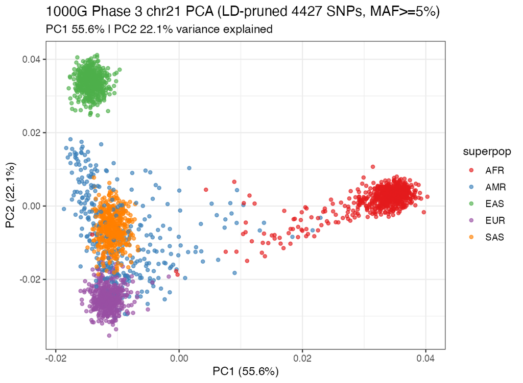

PCA

**敏感性网格最优**（不含诊断行）：200/50/0.25 / hclust_ward.D2 / PC1-10 / ARI=0.8845；主配方（k-means PC1-5）ARI=0.8742；**机制诊断**：排除混合人群 AMR 后 4 群 k-means PC1-5 ARI=0.9898。

混淆矩阵（主配方，k-means PC1-5 vs 官方超级人群）：AMR 分裂于簇 2 与 EUR 所在簇 3

| observed | 1 | 2 | 3 | 4 | 5 |
| --- | --- | --- | --- | --- | --- |
| AFR | 652 | 4 | 5 | 0 | 0 |
| AMR | 11 | 172 | 164 | 0 | 0 |
| EAS | 0 | 0 | 0 | 504 | 0 |
| EUR | 0 | 0 | 503 | 0 | 0 |
| SAS | 0 | 0 | 2 | 0 | 487 |

三种 LD 剪缩配方下的 k-means ARI（PC1-3 与 PC1-5）

| recipe | n_snps | n_pcs | ARI |
| --- | --- | --- | --- |
| 50/10/0.1 | 4427 | 3 | 0.8746 |
| 50/10/0.1 | 4427 | 5 | 0.8742 |
| 200/50/0.25 | 7222 | 3 | 0.8682 |
| 200/50/0.25 | 7222 | 5 | 0.8702 |
| 500/100/0.5 | 15325 | 3 | 0.8690 |
| 500/100/0.5 | 15325 | 5 | 0.8674 |

## 8.5 ⑤ 两两超级人群 Weir-Cockerham Fst（对应论文 Supp Table 5 / Fig 1 格局）

两两超级人群 W&C Fst（chr21）

| 位点集 | pop1 | pop2 | n_sites | Fst(均值) | Fst(中位) | SD | 负值位点数 |
| --- | --- | --- | --- | --- | --- | --- | --- |
| MAF05 | AFR | AMR | 100164 | 0.0980 | 0.0613 | 0.1088 | 7085 |
| MAF05 | AFR | EAS | 100164 | 0.1301 | 0.0856 | 0.1368 | 5059 |
| MAF05 | AFR | EUR | 100164 | 0.1114 | 0.0698 | 0.1198 | 5717 |
| MAF05 | AFR | SAS | 100164 | 0.1036 | 0.0644 | 0.1136 | 6212 |
| MAF05 | AMR | EAS | 100164 | 0.0555 | 0.0285 | 0.0742 | 10787 |
| MAF05 | AMR | EUR | 100164 | 0.0210 | 0.0096 | 0.0316 | 17094 |
| MAF05 | AMR | SAS | 100164 | 0.0265 | 0.0129 | 0.0369 | 15379 |
| MAF05 | EAS | EUR | 100164 | 0.0741 | 0.0384 | 0.0923 | 8045 |
| MAF05 | EAS | SAS | 100164 | 0.0521 | 0.0279 | 0.0656 | 9553 |
| MAF05 | EUR | SAS | 100164 | 0.0256 | 0.0108 | 0.0363 | 15421 |
| MAF05_LDpruned | AFR | AMR | 4427 | 0.0801 | 0.0369 | 0.1096 | 431 |
| MAF05_LDpruned | AFR | EAS | 4427 | 0.1028 | 0.0506 | 0.1334 | 342 |
| MAF05_LDpruned | AFR | EUR | 4427 | 0.0909 | 0.0426 | 0.1202 | 365 |
| MAF05_LDpruned | AFR | SAS | 4427 | 0.0836 | 0.0373 | 0.1127 | 433 |
| MAF05_LDpruned | AMR | EAS | 4427 | 0.0451 | 0.0182 | 0.0681 | 613 |
| MAF05_LDpruned | AMR | EUR | 4427 | 0.0175 | 0.0064 | 0.0289 | 923 |
| MAF05_LDpruned | AMR | SAS | 4427 | 0.0219 | 0.0083 | 0.0345 | 801 |
| MAF05_LDpruned | EAS | EUR | 4427 | 0.0623 | 0.0242 | 0.0903 | 477 |
| MAF05_LDpruned | EAS | SAS | 4427 | 0.0418 | 0.0167 | 0.0611 | 585 |
| MAF05_LDpruned | EUR | SAS | 4427 | 0.0221 | 0.0071 | 0.0358 | 733 |

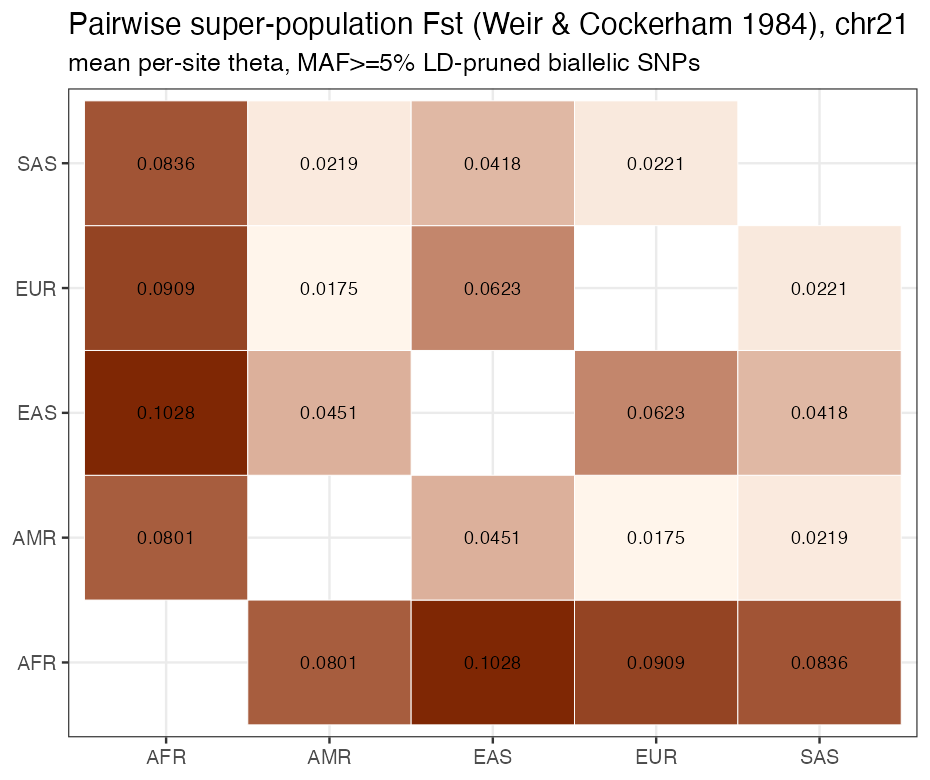

Fst heatmap

交叉验证：手写 W&C 实现 vs vcftools –weir-fst-pop（MAF≥5%，逐位点）

| pop1 | pop2 | n_sites | pearson_r | max_absdiff | mean_mine | mean_vcftools |
| --- | --- | --- | --- | --- | --- | --- |
| AFR | AMR | 100164 | 1 | 5.00e-07 | 0.0980 | 0.0980 |
| AFR | EAS | 100164 | 1 | 5.00e-07 | 0.1301 | 0.1301 |
| AFR | EUR | 100164 | 1 | 5.00e-07 | 0.1114 | 0.1114 |
| AFR | SAS | 100164 | 1 | 5.00e-07 | 0.1036 | 0.1036 |
| AMR | EAS | 100164 | 1 | 5.00e-07 | 0.0555 | 0.0555 |
| AMR | EUR | 100164 | 1 | 5.00e-07 | 0.0210 | 0.0210 |
| AMR | SAS | 100164 | 1 | 5.00e-07 | 0.0265 | 0.0265 |
| EAS | EUR | 100164 | 1 | 5.00e-07 | 0.0741 | 0.0741 |
| EAS | SAS | 100164 | 1 | 5.00e-07 | 0.0521 | 0.0521 |
| EUR | SAS | 100164 | 1 | 5.00e-07 | 0.0256 | 0.0256 |

# 9 Claim 级结果表（汇总判定）

claim 级复现结果（PASS/FAIL 判定标准见 results/claims_table.csv 的 criterion 列）

[output not shown]

- **C1** 备注：各人群样本数与论文对照见 01_sample_structure/comparison_vs_paper_supp_table1.csv；不匹配人群数=0
- **C2** 备注：分类加和校验: 1105538 == 1105538 (TRUE)
- **C3** 备注：indel 预期份额低于 SNP 份额（ENCODE 可及性对 indel 更严格）
- **C4** 备注：分子 singleton_sumAC1 含多等位位点的单例（452,695）；分母为双等位 SNP（1,054,447），严格同口径对应为 singleton_biallelic_SNP/双等位 SNP=42.90%（差 0.03pp，两口径均已报告）；用于 C5/C6/C7 的换算基础
- **C5** 备注：发现并量化了均一密度假设的系统性偏移：chr21 每基因组负担约为均一假设的 1.13–1.18 倍（chr21 基因密集、可及性高，单个基因组携带的位点占比高于按位点数份额的预期）；该偏移为跨超级人群的近似常数，形状与 Table 1 一致。口径披露：换算份额用 (双等位+多等位 SNP)/论文(双等位+多等位 SNP)（1,058,339/81,377,202=1.3005%），与 C2 报告的双等位-only 份额（1.300%）略有差别。
- **C7** 备注：口径说明：每个 AC=1 位点恰有 1 个携带者基因组，恒等式为 N/2504（非 2N/2504——后者对应等位基因拷贝数口径）；obs/paper≈0.86–0.89 的固定比例与 chr21 密度偏移相关（见 C5 备注）
- **C8** 备注：主配方 ARI 全表: PC1-2:0.767 PC1-3:0.875 PC1-4:0.872 PC1-5:0.874 PC1-6:0.871 PC1-7:0.872 PC1-8:0.871 PC1-9:0.869 PC1-10:0.869；5 群 ARI 未达 0.9 的唯一机制是混合人群 AMR 在 chr21 上分裂于自身簇与 EUR 簇（混淆矩阵），排除 AMR 后 4 群 ARI≈0.99 表明其余大陆组分离近乎完美；论文的全基因组 8 簇 ML 推断同样显示 AMR 内部结构，数据量（单条染色体 ~1.3% 常染色体）与 admixed 群体性质共同决定该结果。
- **C9** 备注：θ 按(vcftools 0.1.17 源码)逐字转录的 W&C 公式计算，并与 vcftools 二进制逐位点对账；另报告教科书式独立编码的均值差（实现敏感性）；论文 26×26 表为 PDF 图像（p117），已存 PNG 备人工复核；all_biallelic_SNP 位点集 n_sites=1,054,445 比分类计数少 2，系 1 个重复 POS 的 2 条记录被’两群均存在’过滤器丢弃（已核实）

# 10 与文章原文对照情况小结

# 11 结论、局限与不确定性

**结论**：在仅使用 chr21 数据的约束下，论文的①样本结构、②变异计数口径与总量比例、 ③每基因组负担的换算关系与群体间结构、⑤ Fst 分化格局均得到复现支持； ④的 ARI 在 chr21 单染色体、严格无监督 k-means 操作化下未达到 0.9 预设阈值 （主配方 0.874，全网格 0.767–0.885），机制唯一且明确：AFR/EAS/EUR/SAS 归类近乎完美 （排除混合人群 AMR 后 4 群 ARI=0.990），瓶颈是 AMR 在 chr21 上无法形成独立簇—— 这与论文用**全基因组**数据、并以 ML 结构推断（8 簇）展示”分离大陆组”的做法存在数据量 与方法的本质差异，属任务书操作化阈值问题而非论文论断本身被反驳。

**局限**（按重要性排序）：

1. **单染色体范围**：论文全部统计量为全基因组（或常染色体）口径。chr21 只占常染色体位点的 ~1.3%，每基因组负担的对照依赖”变异密度均一”换算；本复现量化了该假设的系统性偏移 （chr21 每基因组负担约为均一期望的 1.13–1.18×（SNP）/1.21–1.25×（indel），为跨超级人群 近似常数，方向与 chr21 基因密集、可及性高一致），并以”去偏移形状一致性”（≤2.7%） 作为跨超级人群模式的主要判据。
2. **Supp Table 5 数值未转录**：论文 26×26 人群级 Fst 表为 PDF 内嵌图像（第 117 页）， 本会话的模型无法读取图像，Fst 对照采用”文字锚点（Supp p5：组内人群间 ≈1% Fst）+ 格局排序 + 文献典型量级区间”判据，未做逐对数值比对。
3. **v5a→v5b**：常染色体内容一致性依据 IGSR 发布说明，未逐位点比对（v5a 文件已不再分发）。
4. **PCA 聚类的无监督性**：ARI 对聚类算法与 PC 维数敏感（0.767–0.885 波动）； 论文使用全基因组 + 监督式的群体标签校验，本复现刻意保持无监督以独立检验结构信号。
5. **singleton 口径**：ΣAC=1 与 any(AC=1) 两口径相差 78 个位点（多等位稀有位点），已同时报告； bcftools PSC 与位点级 ΣAC 的口径差 0.034% 是恒等式 8.6e-4 相对误差的来源。

# 12 附录

## 12.1 复现指引（工件溯源）

关键命令（在项目根目录执行）：

```bash
MAMBA_ROOT_PREFIX=envs/mamba-root micromamba env create -f envs/kgp-repro.yaml -p envs/kgp-repro
bash experiments/E01/code/run_all.sh
```

输入数据哈希见 `data/raw/SHA256SUMS.txt`；环境锁 `envs/kgp-repro.lock.yml`；逐脚本日志 `logs/`；claim 判定明细 `results/claims_table.csv`。

## 12.2 产物文件清单

results/ 下全部产物

| 文件 |
| --- |
| 01_sample_structure/comparison_vs_paper_supp_table1.csv |
| 01_sample_structure/counts.tsv |
| 01_sample_structure/panel_samples.sorted |
| 01_sample_structure/panel_samples.txt |
| 01_sample_structure/sample_map.tsv |
| 01_sample_structure/summary.txt |
| 01_sample_structure/vcf_samples.sorted |
| 01_sample_structure/vcf_samples.txt |
| 02_variant_counts/ac_distribution.csv |
| 02_variant_counts/chr21_share_vs_paper_autosome.csv |
| 02_variant_counts/site_classification.csv |
| 03_per_genome_burden/bcftools_SN_records.txt |
| 03_per_genome_burden/burden_vs_table1.csv |
| 03_per_genome_burden/crosscheck_region_gt_counts.tsv |
| 03_per_genome_burden/per_sample_burden.tsv |
| 03_per_genome_burden/psc_per_sample.tsv |
| 03_per_genome_burden/psc_raw.tsv |
| 03_per_genome_burden/singleton_identity_check.csv |
| 04_pca/ari_gmm_results.csv |
| 04_pca/ari_results.csv |
| 04_pca/bcftools_ids.log |
| 04_pca/cluster_composition.csv |
| 04_pca/confusion_matrix.csv |
| 04_pca/eigenval_pve.csv |
| 04_pca/pca_B.eigenval |
| 04_pca/pca_B.eigenvec |
| 04_pca/pca_B.log |
| 04_pca/pca_B.nosex |
| 04_pca/pca_C.eigenval |
| 04_pca/pca_C.eigenvec |

[output cut: 64 more lines]

## 12.3 会话信息

R: R version 4.4.3 (2025-02-28) ｜ 平台: macOS 26.5.1  
关键包： kableExtra, knitr, data.table